# Question: 1

Part A

Answer:

The value varies with the increase in the measurement.

Part B  
Answer

Part C  
Answer

we define the likelihood function by reversing the roles of the data vector x and the (distribution) parameter vector θ in f(x| θ), i.e.,

L(θ;x) = f(x| θ)

In MLE, we can assume that we have a likelihood function L(θ;x), where θ is the distribution parameter vector and x is the set of observations. We are interested in finding the value of θ that maximizes the likelihood with given observations (values of x).

The mathematical problem at hand becomes simpler if we assume that the observations (xi) are independent and identically distributed random variables drawn from a Probability Distribution, f0 (where f0 = Normal Distribution)This reduces the Likelihood function to:

L(θ;x)=f0(x1,x2,x3......xn|θ)  
=f0(x1|θ).f0(x2|θ).f0(x3|θ)....f0(x1n|θ)

Part D  
Answer

The least-squares estimator (LSE) is a special case of a maximum-likelihood estimator (MLE). The special case is that the probability distribution used for the likelihood is the normal distribution.

# Question: 2

Part: A

Answer

To Calculate the probability that a student who studies for 40 hours and has an undergrad GPA of 3.5 gets an A in the class.

It suffices to plug in the beta values in the equation for predicted probability

p^(X)=e−6+0.05X1+X2(1+e−6+0.05X1+X2)  
=0.3775.

Part: B

Answer

To Calculate the probability that a student who studies for 40 hours and has an undergrad GPA of 3.5 gets an A in the class.

It suffices to plug in the beta values in the equation for predicted probability.  
p^(X)=e−6+0.05X1+X2(1+e−6+0.05X1+X2)  
=0.3775.

Part: C  
Answer:

The equation for predicted probability tells us that

e−6+0.05X1+3.5(1+e−6+0.05X1+3.5)  
=0.5

which is equivalent to  
e−6+0.05X1+3.5  
=1.

By taking the logarithm of both sides, we get  
X1=2.50.05  
=50.

# Question: 3

```python
# Importing necessary libraries for training and data wrangling
import pandas as pd
import numpy as np
import sklearn as sk
import matplotlib.pyplot as plt
```

```python
# Uploading the data to google colab storage
dataset = pd.read_csv('/content/Weekly.csv')
# dropping unnecessary columns
dataset.drop(columns='Unnamed: 0', inplace=True)
dataset
```

|  | Year | Lag1 | Lag2 | Lag3 | Lag4 | Lag5 | Volume | Today | Direction |
| --- | --- | --- | --- | --- | --- | --- | --- | --- | --- |
| 0 | 1990 | 0.816 | 1.572 | -3.936 | -0.229 | -3.484 | 0.154976 | -0.270 | Down |
| 1 | 1990 | -0.270 | 0.816 | 1.572 | -3.936 | -0.229 | 0.148574 | -2.576 | Down |
| 2 | 1990 | -2.576 | -0.270 | 0.816 | 1.572 | -3.936 | 0.159837 | 3.514 | Up |
| 3 | 1990 | 3.514 | -2.576 | -0.270 | 0.816 | 1.572 | 0.161630 | 0.712 | Up |
| 4 | 1990 | 0.712 | 3.514 | -2.576 | -0.270 | 0.816 | 0.153728 | 1.178 | Up |
| ... | ... | ... | ... | ... | ... | ... | ... | ... | ... |
| 1084 | 2010 | -0.861 | 0.043 | -2.173 | 3.599 | 0.015 | 3.205160 | 2.969 | Up |
| 1085 | 2010 | 2.969 | -0.861 | 0.043 | -2.173 | 3.599 | 4.242568 | 1.281 | Up |
| 1086 | 2010 | 1.281 | 2.969 | -0.861 | 0.043 | -2.173 | 4.835082 | 0.283 | Up |
| 1087 | 2010 | 0.283 | 1.281 | 2.969 | -0.861 | 0.043 | 4.454044 | 1.034 | Up |
| 1088 | 2010 | 1.034 | 0.283 | 1.281 | 2.969 | -0.861 | 2.707105 | 0.069 | Up |

1089 rows × 9 columns

## Task: 01 Splitting Training and Testing Dataset

```python
# splitting the data into training and testing
X_train = dataset.head(985)
X_test = dataset.tail(1089-985)
print(X_train, X_test)
```

```
     Year    Lag1    Lag2    Lag3    Lag4    Lag5    Volume  Today Direction
0    1990   0.816   1.572  -3.936  -0.229  -3.484  0.154976 -0.270      Down
1    1990  -0.270   0.816   1.572  -3.936  -0.229  0.148574 -2.576      Down
2    1990  -2.576  -0.270   0.816   1.572  -3.936  0.159837  3.514        Up
3    1990   3.514  -2.576  -0.270   0.816   1.572  0.161630  0.712        Up
4    1990   0.712   3.514  -2.576  -0.270   0.816  0.153728  1.178        Up
..    ...     ...     ...     ...     ...     ...       ...    ...       ...
980  2008  12.026  -8.389  -6.198  -3.898  10.491  5.841565 -2.251      Down
981  2008  -2.251  12.026  -8.389  -6.198  -3.898  6.093950  0.418        Up
982  2008   0.418  -2.251  12.026  -8.389  -6.198  5.932454  0.926        Up
983  2008   0.926   0.418  -2.251  12.026  -8.389  5.855972 -1.698      Down
984  2008  -1.698   0.926   0.418  -2.251  12.026  3.087105  6.760        Up

[985 rows x 9 columns]       Year   Lag1   Lag2   Lag3   Lag4   Lag5    Volume  Today Direction
985   2009  6.760 -1.698  0.926  0.418 -2.251  3.793110 -4.448      Down
986   2009 -4.448  6.760 -1.698  0.926  0.418  5.043904 -4.518      Down
987   2009 -4.518 -4.448  6.760 -1.698  0.926  5.948758 -2.137      Down
988   2009 -2.137 -4.518 -4.448  6.760 -1.698  6.129763 -0.730      Down
989   2009 -0.730 -2.137 -4.518 -4.448  6.760  5.602004  5.173        Up
...    ...    ...    ...    ...    ...    ...       ...    ...       ...
1084  2010 -0.861  0.043 -2.173  3.599  0.015  3.205160  2.969        Up
1085  2010  2.969 -0.861  0.043 -2.173  3.599  4.242568  1.281        Up
1086  2010  1.281  2.969 -0.861  0.043 -2.173  4.835082  0.283        Up
1087  2010  0.283  1.281  2.969 -0.861  0.043  4.454044  1.034        Up
1088  2010  1.034  0.283  1.281  2.969 -0.861  2.707105  0.069        Up

[104 rows x 9 columns]
```

```python
# Dropping the columns other than features
xtrain = X_train.drop(columns=['Year', 'Today', 'Direction'])
ytrain = X_train['Direction']
```

```python
# Dropping the columns other than features
xtest = X_test.drop(columns=['Year', 'Today', 'Direction'])
ytest = X_test['Direction']
```

### Description of data.

```python
# Description of the Dataset features
print("Training Features\n\n", xtrain.describe())
print("Training Target\n\n", ytrain.describe())
print("Testing Features\n\n", xtest.describe())
print("Testing Target\n\n", ytest.describe())
```

```
Training Features

              Lag1        Lag2        Lag3        Lag4        Lag5      Volume
count  985.000000  985.000000  985.000000  985.000000  985.000000  985.000000
mean     0.124501    0.127820    0.122884    0.122227    0.120976    1.205973
std      2.269346    2.269069    2.272617    2.272625    2.274273    1.258204
min    -18.195000  -18.195000  -18.195000  -18.195000  -18.195000    0.087465
25%     -1.154000   -1.147000   -1.154000   -1.154000   -1.154000    0.307337
50%      0.231000    0.234000    0.231000    0.230000    0.230000    0.804848
75%      1.334000    1.337000    1.337000    1.337000    1.337000    1.515846
max     12.026000   12.026000   12.026000   12.026000   12.026000    9.328214
Training Target

 count     985
unique      2
top        Up
freq      544
Name: Direction, dtype: object
Testing Features

              Lag1        Lag2        Lag3        Lag4        Lag5      Volume
count  104.000000  104.000000  104.000000  104.000000  104.000000  104.000000
mean     0.397635    0.371365    0.377548    0.369250    0.319058    5.066105
std      3.068538    3.074725    3.075192    3.073895    3.073650    1.147652
min     -7.035000   -7.035000   -7.035000   -7.035000   -7.035000    2.390427
25%     -1.060750   -1.214250   -1.214250   -1.214250   -1.323250    4.234228
50%      0.522000    0.461500    0.522000    0.461500    0.437000    4.850717
75%      2.239250    2.239250    2.239250    2.239250    2.204250    5.793837
max     10.707000   10.707000   10.707000   10.707000   10.707000    7.963276
Testing Target

 count     104
unique      2
top        Up
freq       61
Name: Direction, dtype: object
```

## Task: 02 SGD Procedure Usage

Same prebuit Stochiastic Gradient Descent will be used for logistic regression fitting as well. As the model can be controlled for overfitting with SGD.

## Task: 03 Model learning with and without SGD

### Model learning with SGD

```python
# Importing libraries for data visualizations and metrices
import matplotlib.pyplot as plt
import seaborn as sns
from sklearn import metrics
```

```python
# Importing SDG Classifier
from sklearn.linear_model import SGDClassifier
# Setting up the model
with_SGD_Model = SGDClassifier(loss="log", penalty="l2", max_iter=5)
# Fitting the SGD Classifier model
with_SGD_Model.fit(xtrain, ytrain)
```

```
SGDClassifier(loss='log', max_iter=5)
```

```python
# Predicting the SGD Model
with_SGD_Model_predictions = with_SGD_Model.predict(xtest)
with_SGD_Model_predictions
```

```
array(['Up', 'Down', 'Up', 'Down', 'Up', 'Up', 'Down', 'Down', 'Down',
       'Down', 'Up', 'Down', 'Up', 'Down', 'Up', 'Up', 'Up', 'Up', 'Up',
       'Down', 'Up', 'Down', 'Up', 'Up', 'Down', 'Up', 'Down', 'Up', 'Up',
       'Up', 'Up', 'Down', 'Up', 'Up', 'Up', 'Up', 'Up', 'Up', 'Up',
       'Down', 'Up', 'Up', 'Up', 'Down', 'Up', 'Up', 'Up', 'Down', 'Up',
       'Up', 'Up', 'Up', 'Up', 'Up', 'Down', 'Up', 'Down', 'Up', 'Up',
       'Up', 'Up', 'Up', 'Up', 'Up', 'Down', 'Up', 'Up', 'Up', 'Up',
       'Down', 'Down', 'Up', 'Down', 'Up', 'Down', 'Up', 'Down', 'Up',
       'Down', 'Up', 'Up', 'Up', 'Down', 'Up', 'Down', 'Up', 'Down', 'Up',
       'Down', 'Up', 'Down', 'Up', 'Up', 'Up', 'Up', 'Up', 'Up', 'Down',
       'Up', 'Down', 'Up', 'Up', 'Up', 'Down'], dtype='<U4')
```

```python
# Using score function to get accuracy of model
with_SGD_score = with_SGD_Model.score(xtest, ytest)
print(with_SGD_score)
```

```
0.5384615384615384
```

### Learning without SGD

```python
# Importing the Logisitic Regression Model
from sklearn.linear_model import LogisticRegression
without_SGD_Model = LogisticRegression()
```

```python
# Training the model
without_SGD_Model.fit(xtrain, ytrain)
```

```
LogisticRegression()
```

```python
# Use score method to get accuracy of model
without_SGD_score = without_SGD_Model.score(xtest, ytest)
print(without_SGD_score)
```

```
0.46153846153846156
```

```python
# Predicting the model for test dataset
without_SGD_Model_predictions = without_SGD_Model.predict(xtest)
without_SGD_Model_predictions
```

```
array(['Down', 'Up', 'Down', 'Down', 'Down', 'Down', 'Up', 'Down', 'Down',
       'Down', 'Down', 'Up', 'Down', 'Down', 'Down', 'Down', 'Down',
       'Down', 'Down', 'Up', 'Down', 'Down', 'Down', 'Up', 'Down', 'Down',
       'Up', 'Down', 'Down', 'Up', 'Up', 'Down', 'Down', 'Down', 'Down',
       'Down', 'Down', 'Down', 'Up', 'Down', 'Down', 'Up', 'Up', 'Down',
       'Down', 'Down', 'Up', 'Up', 'Down', 'Down', 'Down', 'Down', 'Up',
       'Down', 'Up', 'Down', 'Down', 'Down', 'Up', 'Up', 'Up', 'Down',
       'Down', 'Down', 'Down', 'Down', 'Down', 'Down', 'Down', 'Down',
       'Down', 'Down', 'Up', 'Down', 'Up', 'Down', 'Up', 'Up', 'Down',
       'Down', 'Up', 'Down', 'Up', 'Down', 'Up', 'Down', 'Down', 'Down',
       'Up', 'Down', 'Down', 'Down', 'Down', 'Down', 'Down', 'Down',
       'Down', 'Up', 'Down', 'Up', 'Down', 'Up', 'Down', 'Down'],
      dtype=object)
```

## Task: 04 Cofusion Matrix Function

```python
# Defining the confusion matrix function
def conf_matrix(predicted_values, actual_values):
  cm = metrics.confusion_matrix(actual_values, predicted_values)
  print(cm)
  plt.figure(figsize=(10,10))
  sns.heatmap(cm, annot=True, fmt=".3f", linewidths=.5, square = True, cmap = 'Blues_r')
  plt.ylabel('Actual Values')
  plt.xlabel('Predicted Values')
  plt.title("Confusion Matrix for Predicted and Actual Values", size = 15)
```

## Task: 05

### A: Model without regularization

```
[[31 12]
 [44 17]]
Accuracy: 0.46153846153846156
```

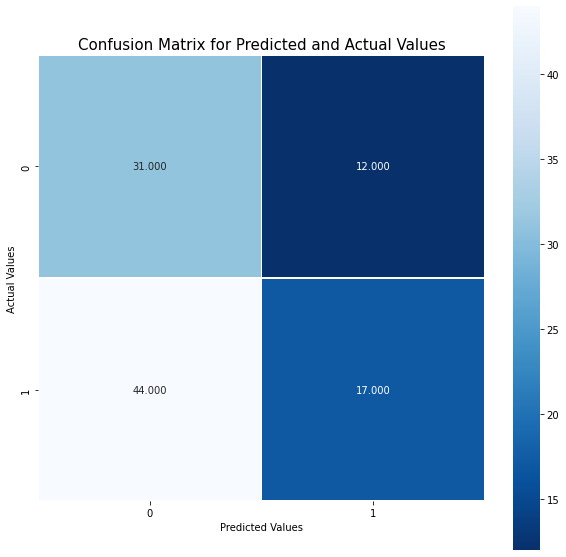

```python
# plot confusion matrix for model without Gradient Descent
conf_matrix(without_SGD_Model_predictions, ytest)
print("Accuracy:", without_SGD_score)
```

### B: Model with Gradient Descent

```
[[14 29]
 [19 42]]
Accuracy: 0.5384615384615384
```

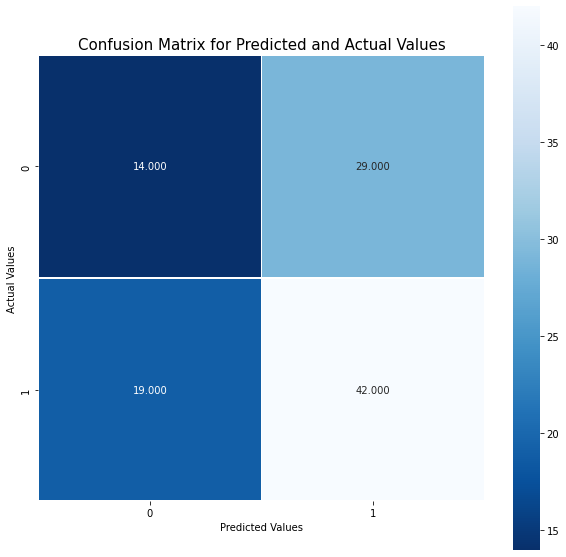

```python
# plot confusion matrix for model without Gradient Descent
conf_matrix(with_SGD_Model_predictions, ytest)
print("Accuracy:", with_SGD_score)
```

## Task: 06 Plot Losses for two models

#### Log Loss

```python
# Importing the Logistic Regression method
from sklearn.metrics import log_loss
```

#### Predicting probablity values of Model without SGD

Training

```python
# Without SGD Model
without_SGD_training_prob = without_SGD_Model.predict_proba(xtrain)
without_SGD_training_prob
```

```
array([[0.36889318, 0.63110682],
       [0.38253764, 0.61746236],
       [0.36513753, 0.63486247],
       ...,
       [0.50409034, 0.49590966],
       [0.56291625, 0.43708375],
       [0.54653507, 0.45346493]])
```

Testing

```python
# Without SGD Model
without_SGD_testing_prob = without_SGD_Model.predict_proba(xtest)
without_SGD_testing_prob
```

```
array([[0.60969555, 0.39030445],
       [0.39135576, 0.60864424],
       [0.55077637, 0.44922363],
       [0.58955137, 0.41044863],
       [0.56605545, 0.43394455],
       [0.55909251, 0.44090749],
       [0.36052772, 0.63947228],
       [0.50105897, 0.49894103],
       [0.60498057, 0.39501943],
       [0.51286899, 0.48713101],
       [0.70077369, 0.29922631],
       [0.3756385 , 0.6243615 ],
       [0.59346907, 0.40653093],
       [0.5619091 , 0.4380909 ],
       [0.67504543, 0.32495457],
       [0.64592206, 0.35407794],
       [0.63840998, 0.36159002],
       [0.6235713 , 0.3764287 ],
       [0.68820335, 0.31179665],
       [0.43200828, 0.56799172],
       [0.64644471, 0.35355529],
       [0.63304205, 0.36695795],
       [0.55691138, 0.44308862],
       [0.48103917, 0.51896083],
       [0.5242452 , 0.4757548 ],
       [0.60951101, 0.39048899],
       [0.49134885, 0.50865115],
       [0.50340038, 0.49659962],
       [0.61548942, 0.38451058],
       [0.48651852, 0.51348148],
       [0.49107589, 0.50892411],
       [0.63589694, 0.36410306],
       [0.60083843, 0.39916157],
       [0.61482473, 0.38517527],
       [0.54851993, 0.45148007],
       [0.53857208, 0.46142792],
       [0.59664974, 0.40335026],
       [0.57880824, 0.42119176],
       [0.47147993, 0.52852007],
       [0.54782649, 0.45217351],
```

[output cut: 49 more lines]

```
       [0.52587288, 0.47412712],
       [0.54406054, 0.45593946],
       [0.52546034, 0.47453966],
       [0.55551542, 0.44448458],
       [0.54137771, 0.45862229],
       [0.54173794, 0.45826206],
       [0.5171371 , 0.4828629 ],
       [0.60371525, 0.39628475],
       [0.45272888, 0.54727112],
       [0.55459068, 0.44540932],
       [0.49443327, 0.50556673],
       [0.58402212, 0.41597788],
       [0.488365  , 0.511635  ],
       [0.51180383, 0.48819617],
       [0.51028088, 0.48971912]])
```

#### Predicting probablity values of Model with SGD

Training

```python
# With SGD Model
with_SGD_training_prob = with_SGD_Model.predict_proba(xtrain)
with_SGD_training_prob
```

```
array([[9.99995851e-01, 4.14887274e-06],
       [1.74584791e-11, 1.00000000e+00],
       [1.00000000e+00, 1.93651759e-11],
       ...,
       [0.00000000e+00, 1.00000000e+00],
       [1.00000000e+00, 3.92376379e-33],
       [0.00000000e+00, 1.00000000e+00]])
```

Testing

```python
# With SGD Model
with_SGD_testing_prob = with_SGD_Model.predict_proba(xtest)
with_SGD_testing_prob
```

```
array([[1.84297022e-14, 1.00000000e+00],
       [9.99999998e-01, 1.76867094e-09],
       [2.29378375e-07, 9.99999771e-01],
       [1.00000000e+00, 4.09313705e-22],
       [8.88178420e-16, 1.00000000e+00],
       [1.23678845e-13, 1.00000000e+00],
       [1.00000000e+00, 6.19906166e-11],
       [9.99999681e-01, 3.19366420e-07],
       [1.00000000e+00, 6.70433824e-23],
       [9.94279000e-01, 5.72099983e-03],
       [0.00000000e+00, 1.00000000e+00],
       [9.99617385e-01, 3.82614994e-04],
       [0.00000000e+00, 1.00000000e+00],
       [1.00000000e+00, 4.33505715e-19],
       [0.00000000e+00, 1.00000000e+00],
       [2.10537388e-02, 9.78946261e-01],
       [4.85087659e-09, 9.99999995e-01],
       [1.49178891e-10, 1.00000000e+00],
       [8.88178420e-16, 1.00000000e+00],
       [9.90098567e-01, 9.90143288e-03],
       [4.85639062e-09, 9.99999995e-01],
       [9.99890648e-01, 1.09351938e-04],
       [0.00000000e+00, 1.00000000e+00],
       [2.86132650e-01, 7.13867350e-01],
       [9.99995379e-01, 4.62058662e-06],
       [1.37655456e-05, 9.99986234e-01],
       [9.98030590e-01, 1.96941042e-03],
       [1.76108168e-05, 9.99982389e-01],
       [1.20552457e-11, 1.00000000e+00],
       [2.04281037e-14, 1.00000000e+00],
       [6.48370246e-14, 1.00000000e+00],
       [9.97470671e-01, 2.52932876e-03],
       [6.16774627e-07, 9.99999383e-01],
       [4.44089210e-16, 1.00000000e+00],
       [3.65605590e-01, 6.34394410e-01],
       [6.68226319e-09, 9.99999993e-01],
       [1.35609500e-04, 9.99864391e-01],
       [1.20345511e-10, 1.00000000e+00],
       [3.23507500e-05, 9.99967649e-01],
       [9.99942393e-01, 5.76070935e-05],
```

[output cut: 49 more lines]

```
       [2.09414708e-11, 1.00000000e+00],
       [5.26609290e-01, 4.73390710e-01],
       [4.07310630e-10, 1.00000000e+00],
       [1.11604049e-07, 9.99999888e-01],
       [4.32845700e-04, 9.99567154e-01],
       [1.18218324e-10, 1.00000000e+00],
       [1.02553569e-01, 8.97446431e-01],
       [8.16680057e-13, 1.00000000e+00],
       [8.64302759e-01, 1.35697241e-01],
       [4.67179140e-09, 9.99999995e-01],
       [9.99999989e-01, 1.13641506e-08],
       [0.00000000e+00, 1.00000000e+00],
       [3.24714143e-02, 9.67528586e-01],
       [1.07418607e-09, 9.99999999e-01],
       [6.21164302e-01, 3.78835698e-01]])
```

### Model without SGD

#### Training Loss

```python
# Calculating logistic loss value
without_SGD_training_loss = log_loss(ytrain, without_SGD_training_prob)
without_SGD_training_loss
```

```
0.6813875468279803
```

#### Testing Loss

```python
# Calculating logistic loss value
without_SGD_testing_loss = log_loss(ytest, without_SGD_testing_prob)
without_SGD_testing_loss
```

```
0.7163296252177602
```

### Model with SGD

#### Training Loss

```python
# Calculating logistic loss value
with_SGD_training_loss = log_loss(ytrain, with_SGD_training_prob)
with_SGD_training_loss
```

```
6.958928464372456
```

#### Testing Loss

```python
# Calculating logistic loss value
with_SGD_testing_loss = log_loss(ytest, with_SGD_testing_prob)
with_SGD_testing_loss
```

```
7.815210774781419
```

### Task: 06 Part: A

The testing loss for the model trained without the SGD, is 0.7163. Meanwhile, the training loss for the same model is 0.6814. This indicates that the model is not showing overfitting while training or testing.

### Task: 06 Part: B

```python
# Training Loss
print(without_SGD_training_loss)
# Testing Loss
print(without_SGD_testing_loss)
```

```
0.6813875468279803
0.7163296252177602
```

### Task: 06 Part: C

Due to the increase in the regularization, the model displayed a comparatively large measure of loss error.

```python
# Training Loss
print(with_SGD_training_loss)
# Testing Loss
print(with_SGD_testing_loss)
```

```
6.958928464372456
7.815210774781419
```

## Task: 08

The increase in the learning rate might cause to skip some instances while training the model. Thus, a moderate value of learning rate parameter has to be set to achieve required accuracy. Whereas, the regularization helps in controlling the overfitting of the model while training, it does have a critical impact as well. Due to the increase in the regularization co-efficient, the model could go into underfitting phenomenon and cause not to meet the required amount of accuracy.

```python
#Printing the accuracy values for both models
print("Accuracy of model without SGD: ", without_SGD_score)
print("Accuracy of model with SGD: ", with_SGD_score)
```

```
Accuracy of model without SGD:  0.46153846153846156
Accuracy of model with SGD:  0.5384615384615384
```

## Task: 09

```python
# Importing the f1_score method
from sklearn.metrics import f1_score
```

[output not shown]

```python
# Training probability values
with_SGD_training_prob
```

```
array([[9.99995851e-01, 4.14887274e-06],
       [1.74584791e-11, 1.00000000e+00],
       [1.00000000e+00, 1.93651759e-11],
       ...,
       [0.00000000e+00, 1.00000000e+00],
       [1.00000000e+00, 3.92376379e-33],
       [0.00000000e+00, 1.00000000e+00]])
```

## Task: 10

```python
# Separating the dataset for training
x_train_lag_data = xtrain[['Lag1', 'Lag2', 'Lag3', 'Lag4', 'Lag5']]
x_train_lag_data
```

|  | Lag1 | Lag2 | Lag3 | Lag4 | Lag5 |
| --- | --- | --- | --- | --- | --- |
| 0 | 0.816 | 1.572 | -3.936 | -0.229 | -3.484 |
| 1 | -0.270 | 0.816 | 1.572 | -3.936 | -0.229 |
| 2 | -2.576 | -0.270 | 0.816 | 1.572 | -3.936 |
| 3 | 3.514 | -2.576 | -0.270 | 0.816 | 1.572 |
| 4 | 0.712 | 3.514 | -2.576 | -0.270 | 0.816 |
| ... | ... | ... | ... | ... | ... |
| 980 | 12.026 | -8.389 | -6.198 | -3.898 | 10.491 |
| 981 | -2.251 | 12.026 | -8.389 | -6.198 | -3.898 |
| 982 | 0.418 | -2.251 | 12.026 | -8.389 | -6.198 |
| 983 | 0.926 | 0.418 | -2.251 | 12.026 | -8.389 |
| 984 | -1.698 | 0.926 | 0.418 | -2.251 | 12.026 |

985 rows × 5 columns

```python
# Separating the dataset for testing
x_test_lag_data = xtest[['Lag1', 'Lag2', 'Lag3', 'Lag4', 'Lag5']]
x_test_lag_data
```

|  | Lag1 | Lag2 | Lag3 | Lag4 | Lag5 |
| --- | --- | --- | --- | --- | --- |
| 985 | 6.760 | -1.698 | 0.926 | 0.418 | -2.251 |
| 986 | -4.448 | 6.760 | -1.698 | 0.926 | 0.418 |
| 987 | -4.518 | -4.448 | 6.760 | -1.698 | 0.926 |
| 988 | -2.137 | -4.518 | -4.448 | 6.760 | -1.698 |
| 989 | -0.730 | -2.137 | -4.518 | -4.448 | 6.760 |
| ... | ... | ... | ... | ... | ... |
| 1084 | -0.861 | 0.043 | -2.173 | 3.599 | 0.015 |
| 1085 | 2.969 | -0.861 | 0.043 | -2.173 | 3.599 |
| 1086 | 1.281 | 2.969 | -0.861 | 0.043 | -2.173 |
| 1087 | 0.283 | 1.281 | 2.969 | -0.861 | 0.043 |
| 1088 | 1.034 | 0.283 | 1.281 | 2.969 | -0.861 |

104 rows × 5 columns

```python
# Separating the dataset for for target values of  training dataset
y_train_lag_data = ytrain
y_train_lag_data
```

```
0      Down
1      Down
2        Up
3        Up
4        Up
       ...
980    Down
981      Up
982      Up
983    Down
984      Up
Name: Direction, Length: 985, dtype: object
```

```python
# Separating the dataset for target values of testing dataset
y_test_lag_data = ytest
y_test_lag_data
```

```
985     Down
986     Down
987     Down
988     Down
989       Up
        ...
1084      Up
1085      Up
1086      Up
1087      Up
1088      Up
Name: Direction, Length: 104, dtype: object
```

### Fitting

Lag 1 Fitting

```python
# Importing the Logistic Regression Model
from sklearn.linear_model import LogisticRegression
# Importing the Logistic Regression Model
lag1_Model = LogisticRegression()
lag1_Model.fit(x_train_lag_data[['Lag1']], y_train_lag_data)

# Use score method to get accuracy of model
lag1_Model_score = lag1_Model.score(x_test_lag_data[['Lag1']], y_test_lag_data)
print("lag1 Model Accuracy: ", lag1_Model_score)
# Predicting the values
lag1_Model_predictions = lag1_Model.predict(x_train_lag_data[['Lag1']])
print("lag1 Model Predictions: \n", lag1_Model_predictions)
```

```
lag1 Model Accuracy:  0.5673076923076923
lag1 Model Predictions:
 ['Up' 'Up' 'Up' 'Up' 'Up' 'Up' 'Up' 'Up' 'Up' 'Up' 'Up' 'Up' 'Up' 'Down'
 'Up' 'Up' 'Up' 'Up' 'Up' 'Up' 'Up' 'Up' 'Up' 'Up' 'Up' 'Up' 'Up' 'Up'
 'Up' 'Up' 'Up' 'Up' 'Up' 'Up' 'Up' 'Up' 'Down' 'Up' 'Up' 'Up' 'Up' 'Up'
 'Up' 'Up' 'Up' 'Up' 'Up' 'Up' 'Up' 'Down' 'Up' 'Up' 'Down' 'Up' 'Up' 'Up'
 'Up' 'Up' 'Up' 'Up' 'Up' 'Up' 'Up' 'Up' 'Up' 'Up' 'Up' 'Up' 'Up' 'Up'
 'Up' 'Up' 'Up' 'Up' 'Up' 'Up' 'Up' 'Up' 'Up' 'Up' 'Up' 'Up' 'Up' 'Up'
 'Up' 'Up' 'Up' 'Up' 'Up' 'Up' 'Up' 'Up' 'Up' 'Up' 'Up' 'Up' 'Up' 'Up'
 'Down' 'Up' 'Up' 'Up' 'Up' 'Up' 'Up' 'Up' 'Up' 'Up' 'Up' 'Up' 'Up' 'Up'
 'Up' 'Up' 'Up' 'Up' 'Up' 'Up' 'Up' 'Up' 'Up' 'Up' 'Up' 'Up' 'Up' 'Up'
 'Up' 'Up' 'Up' 'Up' 'Up' 'Up' 'Up' 'Up' 'Up' 'Up' 'Up' 'Up' 'Up' 'Up'
 'Up' 'Up' 'Up' 'Up' 'Up' 'Up' 'Up' 'Up' 'Up' 'Up' 'Up' 'Up' 'Up' 'Up'
 'Up' 'Up' 'Up' 'Up' 'Up' 'Up' 'Up' 'Up' 'Up' 'Up' 'Up' 'Up' 'Up' 'Up'
 'Up' 'Up' 'Up' 'Up' 'Up' 'Up' 'Up' 'Up' 'Up' 'Up' 'Up' 'Up' 'Up' 'Up'
 'Up' 'Up' 'Up' 'Up' 'Up' 'Up' 'Up' 'Up' 'Up' 'Up' 'Up' 'Up' 'Up' 'Up'
 'Up' 'Up' 'Up' 'Up' 'Up' 'Up' 'Up' 'Up' 'Up' 'Up' 'Up' 'Up' 'Up' 'Up'
 'Up' 'Up' 'Up' 'Up' 'Up' 'Up' 'Up' 'Up' 'Up' 'Up' 'Up' 'Up' 'Up' 'Up'
 'Up' 'Up' 'Up' 'Up' 'Up' 'Up' 'Up' 'Up' 'Up' 'Up' 'Up' 'Up' 'Up' 'Up'
 'Up' 'Up' 'Up' 'Up' 'Up' 'Up' 'Up' 'Up' 'Up' 'Up' 'Up' 'Up' 'Up' 'Up'
 'Up' 'Up' 'Up' 'Up' 'Up' 'Up' 'Up' 'Up' 'Up' 'Up' 'Up' 'Up' 'Up' 'Up'
 'Up' 'Up' 'Up' 'Up' 'Up' 'Up' 'Up' 'Up' 'Up' 'Up' 'Up' 'Up' 'Up' 'Up'
 'Up' 'Up' 'Up' 'Up' 'Up' 'Up' 'Up' 'Up' 'Up' 'Up' 'Up' 'Up' 'Up' 'Up'
 'Up' 'Up' 'Up' 'Up' 'Up' 'Up' 'Up' 'Up' 'Up' 'Up' 'Up' 'Up' 'Up' 'Up'
 'Up' 'Up' 'Up' 'Up' 'Up' 'Up' 'Up' 'Up' 'Up' 'Up' 'Up' 'Up' 'Up' 'Up'
 'Up' 'Up' 'Up' 'Up' 'Up' 'Up' 'Up' 'Up' 'Up' 'Up' 'Up' 'Up' 'Up' 'Up'
 'Up' 'Up' 'Down' 'Up' 'Up' 'Up' 'Up' 'Up' 'Down' 'Up' 'Up' 'Up' 'Up' 'Up'
 'Up' 'Up' 'Down' 'Up' 'Up' 'Up' 'Up' 'Up' 'Up' 'Up' 'Up' 'Up' 'Up' 'Up'
 'Up' 'Up' 'Up' 'Up' 'Up' 'Up' 'Up' 'Up' 'Up' 'Up' 'Up' 'Down' 'Up' 'Down'
 'Up' 'Up' 'Up' 'Up' 'Up' 'Down' 'Up' 'Up' 'Up' 'Up' 'Up' 'Up' 'Up' 'Up'
 'Up' 'Up' 'Up' 'Up' 'Up' 'Up' 'Up' 'Up' 'Up' 'Up' 'Up' 'Up' 'Up' 'Up'
 'Down' 'Up' 'Up' 'Up' 'Up' 'Up' 'Down' 'Up' 'Up' 'Up' 'Up' 'Up' 'Up' 'Up'
 'Up' 'Up' 'Up' 'Up' 'Up' 'Up' 'Up' 'Up' 'Up' 'Up' 'Up' 'Up' 'Up' 'Up'
 'Up' 'Up' 'Up' 'Up' 'Up' 'Up' 'Up' 'Up' 'Up' 'Up' 'Up' 'Up' 'Up' 'Up'
 'Up' 'Up' 'Up' 'Up' 'Up' 'Down' 'Up' 'Up' 'Down' 'Up' 'Up' 'Up' 'Up' 'Up'
 'Up' 'Up' 'Up' 'Down' 'Up' 'Up' 'Down' 'Up' 'Up' 'Up' 'Up' 'Up' 'Up' 'Up'
 'Up' 'Up' 'Down' 'Up' 'Up' 'Up' 'Up' 'Up' 'Up' 'Up' 'Up' 'Up' 'Down' 'Up'
 'Down' 'Up' 'Up' 'Up' 'Up' 'Up' 'Up' 'Up' 'Up' 'Up' 'Up' 'Up' 'Up' 'Up'
 'Down' 'Up' 'Down' 'Down' 'Up' 'Up' 'Up' 'Up' 'Up' 'Up' 'Up' 'Up' 'Up'
 'Up' 'Up' 'Up' 'Up' 'Down' 'Up' 'Up' 'Up' 'Down' 'Up' 'Down' 'Down' 'Up'
```

[output cut: 18 more lines]

```
 'Up' 'Up' 'Up' 'Up' 'Up' 'Up' 'Up' 'Up' 'Up' 'Up' 'Up' 'Up' 'Up' 'Up'
 'Up' 'Up' 'Up' 'Up' 'Up' 'Up' 'Up' 'Up' 'Up' 'Up' 'Up' 'Up' 'Up' 'Up'
 'Up' 'Up' 'Up' 'Up' 'Up' 'Up' 'Up' 'Up' 'Up' 'Up' 'Up' 'Up' 'Up' 'Up'
 'Up' 'Up' 'Up' 'Up' 'Up' 'Up' 'Up' 'Up' 'Up' 'Up' 'Up' 'Up' 'Up' 'Up'
 'Up' 'Up' 'Up' 'Up' 'Up' 'Up' 'Up' 'Up' 'Up' 'Up' 'Up' 'Up' 'Up' 'Up'
 'Up' 'Up' 'Up' 'Up' 'Up' 'Up' 'Up' 'Up' 'Up' 'Up' 'Up' 'Up' 'Up' 'Up'
 'Up' 'Up' 'Up' 'Up' 'Up' 'Up' 'Up' 'Up' 'Up' 'Up' 'Up' 'Up' 'Up' 'Up'
 'Up' 'Up' 'Up' 'Up' 'Up' 'Up' 'Up' 'Up' 'Up' 'Up' 'Up' 'Up' 'Up' 'Up'
 'Up' 'Up' 'Up' 'Up' 'Up' 'Up' 'Up' 'Up' 'Up' 'Up' 'Up' 'Up' 'Up' 'Up'
 'Up' 'Up' 'Up' 'Up' 'Up' 'Up' 'Up' 'Up' 'Up' 'Up' 'Up' 'Up' 'Up' 'Up'
 'Up' 'Up' 'Up' 'Up' 'Up' 'Up' 'Up' 'Up' 'Up' 'Up' 'Up' 'Up' 'Up' 'Up'
 'Up' 'Down' 'Up' 'Up' 'Up' 'Up' 'Up' 'Up' 'Up' 'Up' 'Down' 'Up' 'Down'
 'Up' 'Up' 'Up' 'Up' 'Up' 'Up' 'Up' 'Up' 'Up' 'Up' 'Up' 'Up' 'Up' 'Up'
 'Up' 'Up' 'Up' 'Up' 'Up' 'Up' 'Up' 'Up' 'Up' 'Up' 'Up' 'Down' 'Up' 'Down'
 'Up' 'Up' 'Up' 'Down' 'Up' 'Up' 'Up' 'Up']
```

Lag 2 Fitting

```python
# Training the model
lag2_Model = LogisticRegression()
lag2_Model.fit(x_train_lag_data[['Lag2']], y_train_lag_data)

# Use score method to get accuracy of model
lag2_Model_score = lag1_Model.score(x_test_lag_data[['Lag2']], y_test_lag_data)
print("lag2 Model Accuracy: ", lag1_Model_score)
# Predicting the values
lag2_Model_predictions = lag2_Model.predict(x_train_lag_data[['Lag2']])
print("lag2 Model Predictions: \n", lag2_Model_predictions)
```

```
lag2 Model Accuracy:  0.5673076923076923
lag2 Model Predictions:
 ['Up' 'Up' 'Up' 'Up' 'Up' 'Up' 'Up' 'Up' 'Up' 'Up' 'Up' 'Up' 'Up' 'Up'
 'Up' 'Up' 'Up' 'Up' 'Up' 'Up' 'Up' 'Up' 'Up' 'Up' 'Up' 'Up' 'Up' 'Up'
 'Up' 'Down' 'Up' 'Up' 'Up' 'Up' 'Up' 'Up' 'Down' 'Up' 'Up' 'Up' 'Up' 'Up'
 'Up' 'Up' 'Up' 'Up' 'Up' 'Up' 'Up' 'Up' 'Up' 'Up' 'Up' 'Up' 'Up' 'Up'
 'Up' 'Up' 'Up' 'Up' 'Up' 'Up' 'Up' 'Up' 'Up' 'Up' 'Up' 'Up' 'Up' 'Up'
 'Up' 'Up' 'Up' 'Up' 'Up' 'Up' 'Up' 'Up' 'Up' 'Up' 'Up' 'Up' 'Up' 'Up'
 'Up' 'Up' 'Up' 'Up' 'Up' 'Up' 'Up' 'Up' 'Up' 'Up' 'Up' 'Up' 'Up' 'Up'
 'Up' 'Up' 'Up' 'Up' 'Up' 'Up' 'Up' 'Up' 'Up' 'Up' 'Up' 'Up' 'Up' 'Up'
 'Up' 'Up' 'Up' 'Up' 'Up' 'Up' 'Up' 'Up' 'Up' 'Up' 'Up' 'Up' 'Up' 'Up'
 'Up' 'Up' 'Up' 'Up' 'Up' 'Up' 'Up' 'Up' 'Up' 'Up' 'Up' 'Up' 'Up' 'Up'
 'Up' 'Up' 'Up' 'Up' 'Up' 'Up' 'Up' 'Up' 'Up' 'Up' 'Up' 'Up' 'Up' 'Up'
 'Up' 'Up' 'Up' 'Up' 'Up' 'Up' 'Up' 'Up' 'Up' 'Up' 'Up' 'Up' 'Up' 'Up'
 'Up' 'Up' 'Up' 'Up' 'Up' 'Up' 'Up' 'Up' 'Up' 'Up' 'Up' 'Up' 'Up' 'Up'
 'Up' 'Up' 'Up' 'Up' 'Up' 'Up' 'Up' 'Up' 'Up' 'Up' 'Up' 'Up' 'Up' 'Up'
 'Up' 'Up' 'Up' 'Up' 'Up' 'Up' 'Up' 'Up' 'Up' 'Up' 'Up' 'Up' 'Up' 'Up'
 'Up' 'Up' 'Up' 'Up' 'Up' 'Up' 'Up' 'Up' 'Up' 'Up' 'Up' 'Up' 'Up' 'Up'
 'Up' 'Up' 'Up' 'Up' 'Up' 'Up' 'Up' 'Up' 'Up' 'Up' 'Up' 'Up' 'Up' 'Up'
 'Up' 'Up' 'Up' 'Up' 'Up' 'Up' 'Up' 'Up' 'Up' 'Up' 'Up' 'Up' 'Up' 'Up'
 'Up' 'Up' 'Up' 'Up' 'Up' 'Up' 'Up' 'Up' 'Up' 'Up' 'Up' 'Up' 'Up' 'Up'
 'Up' 'Up' 'Up' 'Up' 'Up' 'Up' 'Up' 'Up' 'Up' 'Up' 'Up' 'Up' 'Up' 'Up'
 'Up' 'Up' 'Up' 'Up' 'Up' 'Up' 'Up' 'Up' 'Up' 'Up' 'Up' 'Up' 'Up' 'Up'
 'Up' 'Up' 'Up' 'Up' 'Up' 'Up' 'Up' 'Up' 'Up' 'Up' 'Up' 'Up' 'Up' 'Up'
 'Up' 'Up' 'Up' 'Up' 'Up' 'Up' 'Up' 'Up' 'Up' 'Up' 'Up' 'Up' 'Up' 'Up'
 'Up' 'Up' 'Up' 'Up' 'Up' 'Up' 'Up' 'Up' 'Up' 'Up' 'Up' 'Up' 'Up' 'Up'
 'Up' 'Up' 'Up' 'Up' 'Up' 'Up' 'Up' 'Up' 'Up' 'Up' 'Up' 'Up' 'Up' 'Up'
 'Up' 'Up' 'Up' 'Up' 'Up' 'Up' 'Up' 'Up' 'Up' 'Up' 'Up' 'Up' 'Up' 'Up'
 'Up' 'Up' 'Up' 'Up' 'Up' 'Up' 'Up' 'Up' 'Up' 'Up' 'Up' 'Up' 'Up' 'Up'
 'Up' 'Up' 'Up' 'Up' 'Up' 'Up' 'Up' 'Up' 'Up' 'Up' 'Up' 'Up' 'Up' 'Up'
 'Up' 'Down' 'Up' 'Up' 'Up' 'Up' 'Up' 'Up' 'Up' 'Up' 'Up' 'Up' 'Up' 'Up'
 'Up' 'Up' 'Up' 'Up' 'Up' 'Up' 'Up' 'Up' 'Down' 'Up' 'Up' 'Up' 'Up' 'Up'
 'Up' 'Up' 'Up' 'Up' 'Up' 'Up' 'Up' 'Up' 'Up' 'Up' 'Up' 'Up' 'Up' 'Up'
 'Up' 'Up' 'Up' 'Up' 'Up' 'Up' 'Up' 'Up' 'Down' 'Up' 'Up' 'Up' 'Up' 'Down'
 'Down' 'Up' 'Up' 'Up' 'Down' 'Up' 'Up' 'Up' 'Up' 'Up' 'Up' 'Up' 'Up' 'Up'
 'Up' 'Up' 'Up' 'Up' 'Up' 'Up' 'Up' 'Up' 'Up' 'Up' 'Up' 'Up' 'Up' 'Up'
 'Up' 'Up' 'Up' 'Up' 'Up' 'Up' 'Up' 'Up' 'Up' 'Up' 'Up' 'Up' 'Up' 'Up'
 'Up' 'Up' 'Up' 'Up' 'Down' 'Up' 'Up' 'Up' 'Up' 'Up' 'Up' 'Up' 'Up' 'Down'
 'Up' 'Up' 'Down' 'Up' 'Up' 'Up' 'Up' 'Up' 'Up' 'Up' 'Up' 'Up' 'Up' 'Up'
 'Up' 'Up' 'Up' 'Down' 'Up' 'Up' 'Up' 'Up' 'Up' 'Up' 'Up' 'Up' 'Up' 'Up'
```

[output cut: 18 more lines]

```
 'Up' 'Up' 'Up' 'Up' 'Up' 'Up' 'Up' 'Up' 'Up' 'Up' 'Up' 'Up' 'Up' 'Up'
 'Up' 'Up' 'Up' 'Up' 'Up' 'Up' 'Up' 'Up' 'Up' 'Up' 'Up' 'Up' 'Up' 'Up'
 'Up' 'Up' 'Up' 'Up' 'Up' 'Up' 'Up' 'Up' 'Up' 'Up' 'Up' 'Up' 'Up' 'Up'
 'Up' 'Up' 'Up' 'Up' 'Up' 'Up' 'Up' 'Up' 'Up' 'Up' 'Up' 'Up' 'Up' 'Up'
 'Up' 'Up' 'Up' 'Up' 'Up' 'Up' 'Up' 'Up' 'Up' 'Up' 'Up' 'Up' 'Up' 'Up'
 'Up' 'Up' 'Up' 'Up' 'Up' 'Up' 'Up' 'Up' 'Up' 'Up' 'Up' 'Up' 'Up' 'Up'
 'Up' 'Up' 'Up' 'Up' 'Up' 'Up' 'Up' 'Up' 'Up' 'Up' 'Up' 'Up' 'Up' 'Up'
 'Up' 'Up' 'Up' 'Up' 'Up' 'Up' 'Up' 'Up' 'Up' 'Up' 'Down' 'Up' 'Up' 'Up'
 'Up' 'Up' 'Up' 'Up' 'Up' 'Up' 'Up' 'Up' 'Up' 'Up' 'Up' 'Up' 'Up' 'Up'
 'Up' 'Up' 'Up' 'Down' 'Up' 'Up' 'Up' 'Up' 'Up' 'Up' 'Up' 'Up' 'Up' 'Up'
 'Up' 'Down' 'Up' 'Up' 'Down' 'Up' 'Up' 'Up' 'Up' 'Up' 'Up' 'Up' 'Down'
 'Up' 'Down' 'Up' 'Up' 'Down' 'Up' 'Up' 'Up' 'Up' 'Up' 'Up' 'Up' 'Up' 'Up'
 'Up' 'Up' 'Up' 'Up' 'Up' 'Up' 'Up' 'Up' 'Up' 'Up' 'Up' 'Up' 'Up' 'Up'
 'Up' 'Up' 'Up' 'Up' 'Up' 'Up' 'Up' 'Up' 'Up' 'Up' 'Down' 'Down' 'Up'
 'Down' 'Up' 'Down' 'Down' 'Down' 'Up' 'Up' 'Up' 'Up']
```

Lag 3 Fitting

```python
# Importing the Logistic Regression Model
lag3_Model = LogisticRegression()
lag3_Model.fit(x_train_lag_data[['Lag3']], y_train_lag_data)

# Use score method to get accuracy of model
lag3_Model_score = lag1_Model.score(x_test_lag_data[['Lag3']], y_test_lag_data)
print("lag3 Model Accuracy: ", lag1_Model_score)
# Predicting the values
lag3_Model_predictions = lag3_Model.predict(x_train_lag_data[['Lag3']])
print("lag3 Model Predictions: \n", lag3_Model_predictions)
```

```
lag3 Model Accuracy:  0.5673076923076923
lag3 Model Predictions:
 ['Up' 'Up' 'Up' 'Up' 'Up' 'Up' 'Up' 'Up' 'Up' 'Up' 'Up' 'Up' 'Up' 'Up'
 'Up' 'Up' 'Up' 'Up' 'Up' 'Up' 'Up' 'Up' 'Up' 'Up' 'Up' 'Up' 'Up' 'Up'
 'Up' 'Up' 'Up' 'Up' 'Up' 'Up' 'Up' 'Up' 'Up' 'Up' 'Up' 'Up' 'Up' 'Up'
 'Up' 'Up' 'Up' 'Up' 'Up' 'Up' 'Up' 'Up' 'Up' 'Up' 'Up' 'Up' 'Up' 'Up'
 'Up' 'Up' 'Up' 'Up' 'Up' 'Up' 'Up' 'Up' 'Up' 'Up' 'Up' 'Up' 'Up' 'Up'
 'Up' 'Up' 'Up' 'Up' 'Up' 'Up' 'Up' 'Up' 'Up' 'Up' 'Up' 'Up' 'Up' 'Up'
 'Up' 'Up' 'Up' 'Up' 'Up' 'Up' 'Up' 'Up' 'Up' 'Up' 'Up' 'Up' 'Up' 'Up'
 'Up' 'Up' 'Up' 'Up' 'Up' 'Up' 'Up' 'Up' 'Up' 'Up' 'Up' 'Up' 'Up' 'Up'
 'Up' 'Up' 'Up' 'Up' 'Up' 'Up' 'Up' 'Up' 'Up' 'Up' 'Up' 'Up' 'Up' 'Up'
 'Up' 'Up' 'Up' 'Up' 'Up' 'Up' 'Up' 'Up' 'Up' 'Up' 'Up' 'Up' 'Up' 'Up'
 'Up' 'Up' 'Up' 'Up' 'Up' 'Up' 'Up' 'Up' 'Up' 'Up' 'Up' 'Up' 'Up' 'Up'
 'Up' 'Up' 'Up' 'Up' 'Up' 'Up' 'Up' 'Up' 'Up' 'Up' 'Up' 'Up' 'Up' 'Up'
 'Up' 'Up' 'Up' 'Up' 'Up' 'Up' 'Up' 'Up' 'Up' 'Up' 'Up' 'Up' 'Up' 'Up'
 'Up' 'Up' 'Up' 'Up' 'Up' 'Up' 'Up' 'Up' 'Up' 'Up' 'Up' 'Up' 'Up' 'Up'
 'Up' 'Up' 'Up' 'Up' 'Up' 'Up' 'Up' 'Up' 'Up' 'Up' 'Up' 'Up' 'Up' 'Up'
 'Up' 'Up' 'Up' 'Up' 'Up' 'Up' 'Up' 'Up' 'Up' 'Up' 'Up' 'Up' 'Up' 'Up'
 'Up' 'Up' 'Up' 'Up' 'Up' 'Up' 'Up' 'Up' 'Up' 'Up' 'Up' 'Up' 'Up' 'Up'
 'Up' 'Up' 'Up' 'Up' 'Up' 'Up' 'Up' 'Up' 'Up' 'Up' 'Up' 'Up' 'Up' 'Up'
 'Up' 'Up' 'Up' 'Up' 'Up' 'Up' 'Up' 'Up' 'Up' 'Up' 'Up' 'Up' 'Up' 'Up'
 'Up' 'Up' 'Up' 'Up' 'Up' 'Up' 'Up' 'Up' 'Up' 'Up' 'Up' 'Up' 'Up' 'Up'
 'Up' 'Up' 'Up' 'Up' 'Up' 'Up' 'Up' 'Up' 'Up' 'Up' 'Up' 'Up' 'Up' 'Up'
 'Up' 'Up' 'Up' 'Up' 'Up' 'Up' 'Up' 'Up' 'Up' 'Up' 'Up' 'Up' 'Up' 'Up'
 'Up' 'Up' 'Up' 'Up' 'Up' 'Up' 'Up' 'Up' 'Up' 'Up' 'Up' 'Up' 'Up' 'Up'
 'Up' 'Up' 'Up' 'Up' 'Up' 'Up' 'Up' 'Up' 'Up' 'Up' 'Up' 'Up' 'Up' 'Up'
 'Up' 'Up' 'Up' 'Up' 'Up' 'Up' 'Up' 'Up' 'Up' 'Up' 'Up' 'Up' 'Up' 'Up'
 'Up' 'Up' 'Up' 'Up' 'Up' 'Up' 'Up' 'Up' 'Up' 'Up' 'Up' 'Up' 'Up' 'Up'
 'Up' 'Up' 'Up' 'Up' 'Up' 'Up' 'Up' 'Up' 'Up' 'Up' 'Up' 'Up' 'Up' 'Up'
 'Up' 'Up' 'Up' 'Up' 'Up' 'Up' 'Up' 'Up' 'Up' 'Up' 'Up' 'Up' 'Up' 'Up'
 'Up' 'Up' 'Up' 'Up' 'Up' 'Up' 'Up' 'Up' 'Up' 'Up' 'Up' 'Up' 'Up' 'Up'
 'Up' 'Up' 'Up' 'Up' 'Up' 'Up' 'Up' 'Up' 'Up' 'Up' 'Up' 'Up' 'Up' 'Up'
 'Up' 'Up' 'Up' 'Up' 'Up' 'Up' 'Up' 'Up' 'Up' 'Up' 'Up' 'Up' 'Up' 'Up'
 'Up' 'Up' 'Up' 'Up' 'Up' 'Up' 'Up' 'Up' 'Up' 'Up' 'Up' 'Up' 'Up' 'Up'
 'Up' 'Up' 'Up' 'Up' 'Up' 'Up' 'Up' 'Up' 'Up' 'Up' 'Up' 'Up' 'Up' 'Up'
 'Up' 'Up' 'Up' 'Up' 'Up' 'Up' 'Up' 'Up' 'Up' 'Up' 'Up' 'Up' 'Up' 'Up'
 'Up' 'Up' 'Up' 'Up' 'Up' 'Up' 'Up' 'Up' 'Up' 'Up' 'Up' 'Up' 'Up' 'Up'
 'Up' 'Up' 'Up' 'Up' 'Up' 'Up' 'Up' 'Up' 'Up' 'Up' 'Up' 'Up' 'Up' 'Up'
 'Up' 'Up' 'Up' 'Up' 'Up' 'Up' 'Up' 'Up' 'Up' 'Up' 'Up' 'Up' 'Up' 'Up'
 'Up' 'Up' 'Up' 'Up' 'Up' 'Up' 'Up' 'Up' 'Up' 'Up' 'Up' 'Up' 'Up' 'Up'
```

[output cut: 18 more lines]

```
 'Up' 'Up' 'Up' 'Up' 'Up' 'Up' 'Up' 'Up' 'Up' 'Up' 'Up' 'Up' 'Up' 'Up'
 'Up' 'Up' 'Up' 'Up' 'Up' 'Up' 'Up' 'Up' 'Up' 'Up' 'Up' 'Up' 'Up' 'Up'
 'Up' 'Up' 'Up' 'Up' 'Up' 'Up' 'Up' 'Up' 'Up' 'Up' 'Up' 'Up' 'Up' 'Up'
 'Up' 'Up' 'Up' 'Up' 'Up' 'Up' 'Up' 'Up' 'Up' 'Up' 'Up' 'Up' 'Up' 'Up'
 'Up' 'Up' 'Up' 'Up' 'Up' 'Up' 'Up' 'Up' 'Up' 'Up' 'Up' 'Up' 'Up' 'Up'
 'Up' 'Up' 'Up' 'Up' 'Up' 'Up' 'Up' 'Up' 'Up' 'Up' 'Up' 'Up' 'Up' 'Up'
 'Up' 'Up' 'Up' 'Up' 'Up' 'Up' 'Up' 'Up' 'Up' 'Up' 'Up' 'Up' 'Up' 'Up'
 'Up' 'Up' 'Up' 'Up' 'Up' 'Up' 'Up' 'Up' 'Up' 'Up' 'Up' 'Up' 'Up' 'Up'
 'Up' 'Up' 'Up' 'Up' 'Up' 'Up' 'Up' 'Up' 'Up' 'Up' 'Up' 'Up' 'Up' 'Up'
 'Up' 'Up' 'Up' 'Up' 'Up' 'Up' 'Up' 'Up' 'Up' 'Up' 'Up' 'Up' 'Up' 'Up'
 'Up' 'Up' 'Up' 'Up' 'Up' 'Up' 'Up' 'Up' 'Up' 'Up' 'Up' 'Up' 'Up' 'Up'
 'Up' 'Up' 'Up' 'Up' 'Up' 'Up' 'Up' 'Up' 'Up' 'Up' 'Up' 'Up' 'Up' 'Up'
 'Up' 'Up' 'Up' 'Up' 'Up' 'Up' 'Up' 'Up' 'Up' 'Up' 'Up' 'Up' 'Up' 'Up'
 'Up' 'Up' 'Up' 'Up' 'Up' 'Up' 'Up' 'Up' 'Up' 'Up' 'Up' 'Up' 'Up' 'Up'
 'Up' 'Up' 'Up' 'Up' 'Up']
```

Lag 4 Fitting

```python
# Importing the Logistic Regression Model
lag4_Model = LogisticRegression()
lag4_Model.fit(x_train_lag_data[['Lag4']], y_train_lag_data)

# Use score method to get accuracy of model
lag4_Model_score = lag1_Model.score(x_test_lag_data[['Lag4']], y_test_lag_data)
print("lag4 Model Accuracy: ", lag1_Model_score)
# Predicting the values
lag4_Model_predictions = lag4_Model.predict(x_train_lag_data[['Lag4']])
print("lag4 Model Predictions: \n", lag4_Model_predictions)
```

```
lag4 Model Accuracy:  0.5673076923076923
lag4 Model Predictions:
 ['Up' 'Up' 'Up' 'Up' 'Up' 'Up' 'Up' 'Up' 'Up' 'Up' 'Up' 'Up' 'Up' 'Up'
 'Up' 'Up' 'Up' 'Up' 'Up' 'Up' 'Up' 'Up' 'Up' 'Up' 'Up' 'Up' 'Up' 'Up'
 'Up' 'Up' 'Up' 'Up' 'Up' 'Up' 'Up' 'Up' 'Up' 'Up' 'Up' 'Up' 'Up' 'Up'
 'Up' 'Up' 'Up' 'Up' 'Up' 'Up' 'Up' 'Up' 'Up' 'Up' 'Up' 'Up' 'Up' 'Up'
 'Up' 'Up' 'Up' 'Up' 'Up' 'Up' 'Up' 'Up' 'Up' 'Up' 'Up' 'Up' 'Up' 'Up'
 'Up' 'Up' 'Up' 'Up' 'Up' 'Up' 'Up' 'Up' 'Up' 'Up' 'Up' 'Up' 'Up' 'Up'
 'Up' 'Up' 'Up' 'Up' 'Up' 'Up' 'Up' 'Up' 'Up' 'Up' 'Up' 'Up' 'Up' 'Up'
 'Up' 'Up' 'Up' 'Up' 'Up' 'Up' 'Up' 'Up' 'Up' 'Up' 'Up' 'Up' 'Up' 'Up'
 'Up' 'Up' 'Up' 'Up' 'Up' 'Up' 'Up' 'Up' 'Up' 'Up' 'Up' 'Up' 'Up' 'Up'
 'Up' 'Up' 'Up' 'Up' 'Up' 'Up' 'Up' 'Up' 'Up' 'Up' 'Up' 'Up' 'Up' 'Up'
 'Up' 'Up' 'Up' 'Up' 'Up' 'Up' 'Up' 'Up' 'Up' 'Up' 'Up' 'Up' 'Up' 'Up'
 'Up' 'Up' 'Up' 'Up' 'Up' 'Up' 'Up' 'Up' 'Up' 'Up' 'Up' 'Up' 'Up' 'Up'
 'Up' 'Up' 'Up' 'Up' 'Up' 'Up' 'Up' 'Up' 'Up' 'Up' 'Up' 'Up' 'Up' 'Up'
 'Up' 'Up' 'Up' 'Up' 'Up' 'Up' 'Up' 'Up' 'Up' 'Up' 'Up' 'Up' 'Up' 'Up'
 'Up' 'Up' 'Up' 'Up' 'Up' 'Up' 'Up' 'Up' 'Up' 'Up' 'Up' 'Up' 'Up' 'Up'
 'Up' 'Up' 'Up' 'Up' 'Up' 'Up' 'Up' 'Up' 'Up' 'Up' 'Up' 'Up' 'Up' 'Up'
 'Up' 'Up' 'Up' 'Up' 'Up' 'Up' 'Up' 'Up' 'Up' 'Up' 'Up' 'Up' 'Up' 'Up'
 'Up' 'Up' 'Up' 'Up' 'Up' 'Up' 'Up' 'Up' 'Up' 'Up' 'Up' 'Up' 'Up' 'Up'
 'Up' 'Up' 'Up' 'Up' 'Up' 'Up' 'Up' 'Up' 'Up' 'Up' 'Up' 'Up' 'Up' 'Up'
 'Up' 'Up' 'Up' 'Up' 'Up' 'Up' 'Up' 'Up' 'Up' 'Up' 'Up' 'Up' 'Up' 'Up'
 'Up' 'Up' 'Up' 'Up' 'Up' 'Up' 'Up' 'Up' 'Up' 'Up' 'Up' 'Up' 'Up' 'Up'
 'Up' 'Up' 'Up' 'Up' 'Up' 'Up' 'Up' 'Up' 'Up' 'Up' 'Up' 'Up' 'Up' 'Up'
 'Up' 'Up' 'Up' 'Up' 'Up' 'Up' 'Up' 'Up' 'Up' 'Up' 'Up' 'Up' 'Up' 'Up'
 'Up' 'Up' 'Up' 'Up' 'Up' 'Up' 'Up' 'Up' 'Up' 'Up' 'Up' 'Up' 'Up' 'Up'
 'Up' 'Up' 'Up' 'Up' 'Up' 'Up' 'Up' 'Up' 'Up' 'Up' 'Up' 'Up' 'Up' 'Up'
 'Up' 'Up' 'Up' 'Up' 'Up' 'Up' 'Up' 'Up' 'Up' 'Up' 'Up' 'Up' 'Up' 'Up'
 'Up' 'Up' 'Up' 'Up' 'Up' 'Up' 'Up' 'Up' 'Up' 'Up' 'Up' 'Up' 'Up' 'Up'
 'Up' 'Up' 'Up' 'Up' 'Up' 'Up' 'Up' 'Up' 'Up' 'Up' 'Up' 'Up' 'Up' 'Up'
 'Up' 'Up' 'Up' 'Up' 'Up' 'Up' 'Up' 'Up' 'Up' 'Up' 'Up' 'Up' 'Up' 'Up'
 'Up' 'Up' 'Up' 'Up' 'Up' 'Up' 'Up' 'Up' 'Up' 'Up' 'Up' 'Up' 'Up' 'Up'
 'Up' 'Up' 'Up' 'Up' 'Up' 'Up' 'Up' 'Up' 'Up' 'Up' 'Up' 'Up' 'Up' 'Up'
 'Up' 'Up' 'Up' 'Up' 'Up' 'Up' 'Up' 'Up' 'Up' 'Up' 'Up' 'Up' 'Up' 'Up'
 'Up' 'Up' 'Up' 'Up' 'Up' 'Up' 'Up' 'Up' 'Up' 'Up' 'Up' 'Up' 'Up' 'Up'
 'Up' 'Up' 'Up' 'Up' 'Up' 'Up' 'Up' 'Up' 'Up' 'Up' 'Up' 'Up' 'Up' 'Up'
 'Up' 'Up' 'Up' 'Up' 'Up' 'Up' 'Up' 'Up' 'Up' 'Up' 'Up' 'Up' 'Up' 'Up'
 'Up' 'Up' 'Up' 'Up' 'Up' 'Up' 'Up' 'Up' 'Up' 'Up' 'Up' 'Up' 'Up' 'Up'
 'Up' 'Up' 'Up' 'Up' 'Up' 'Up' 'Up' 'Up' 'Up' 'Up' 'Up' 'Up' 'Up' 'Up'
 'Up' 'Up' 'Up' 'Up' 'Up' 'Up' 'Up' 'Up' 'Up' 'Up' 'Up' 'Up' 'Up' 'Up'
```

[output cut: 18 more lines]

```
 'Up' 'Up' 'Up' 'Up' 'Up' 'Up' 'Up' 'Up' 'Up' 'Up' 'Up' 'Up' 'Up' 'Up'
 'Up' 'Up' 'Up' 'Up' 'Up' 'Up' 'Up' 'Up' 'Up' 'Up' 'Up' 'Up' 'Up' 'Up'
 'Up' 'Up' 'Up' 'Up' 'Up' 'Up' 'Up' 'Up' 'Up' 'Up' 'Up' 'Up' 'Up' 'Up'
 'Up' 'Up' 'Up' 'Up' 'Up' 'Up' 'Up' 'Up' 'Up' 'Up' 'Up' 'Up' 'Up' 'Up'
 'Up' 'Up' 'Up' 'Up' 'Up' 'Up' 'Up' 'Up' 'Up' 'Up' 'Up' 'Up' 'Up' 'Up'
 'Up' 'Up' 'Up' 'Up' 'Up' 'Up' 'Up' 'Up' 'Up' 'Up' 'Up' 'Up' 'Up' 'Up'
 'Up' 'Up' 'Up' 'Up' 'Up' 'Up' 'Up' 'Up' 'Up' 'Up' 'Up' 'Up' 'Up' 'Up'
 'Up' 'Up' 'Up' 'Up' 'Up' 'Up' 'Up' 'Up' 'Up' 'Up' 'Up' 'Up' 'Up' 'Up'
 'Up' 'Up' 'Up' 'Up' 'Up' 'Up' 'Up' 'Up' 'Up' 'Up' 'Up' 'Up' 'Up' 'Up'
 'Up' 'Up' 'Up' 'Up' 'Up' 'Up' 'Up' 'Up' 'Up' 'Up' 'Up' 'Up' 'Up' 'Up'
 'Up' 'Up' 'Up' 'Up' 'Up' 'Up' 'Up' 'Up' 'Up' 'Up' 'Up' 'Up' 'Up' 'Up'
 'Up' 'Up' 'Up' 'Up' 'Up' 'Up' 'Up' 'Up' 'Up' 'Up' 'Up' 'Up' 'Up' 'Up'
 'Up' 'Up' 'Up' 'Up' 'Up' 'Up' 'Up' 'Up' 'Up' 'Up' 'Up' 'Up' 'Up' 'Up'
 'Up' 'Up' 'Up' 'Up' 'Up' 'Up' 'Up' 'Up' 'Up' 'Up' 'Up' 'Up' 'Up' 'Up'
 'Up' 'Up' 'Up' 'Up' 'Up']
```

Lag 5 Fitting

```python
# Importing the Logistic Regression Model
lag5_Model = LogisticRegression()
lag5_Model.fit(x_train_lag_data[['Lag5']], y_train_lag_data)

# Use score method to get accuracy of model
lag5_Model_score = lag1_Model.score(x_test_lag_data[['Lag5']], y_test_lag_data)
print("lag5 Model Accuracy: ", lag1_Model_score)
# Predicting the values
lag5_Model_predictions = lag5_Model.predict(x_train_lag_data[['Lag5']])
print("lag5 Model Predictions: \n", lag5_Model_predictions)
```

```
lag5 Model Accuracy:  0.5673076923076923
lag5 Model Predictions:
 ['Up' 'Up' 'Up' 'Up' 'Up' 'Up' 'Up' 'Up' 'Up' 'Up' 'Up' 'Up' 'Up' 'Up'
 'Up' 'Up' 'Up' 'Up' 'Up' 'Up' 'Up' 'Up' 'Up' 'Up' 'Up' 'Up' 'Up' 'Up'
 'Up' 'Up' 'Up' 'Up' 'Up' 'Up' 'Up' 'Up' 'Up' 'Up' 'Up' 'Up' 'Up' 'Up'
 'Up' 'Up' 'Up' 'Up' 'Up' 'Up' 'Up' 'Up' 'Up' 'Up' 'Up' 'Up' 'Up' 'Up'
 'Up' 'Up' 'Up' 'Up' 'Up' 'Up' 'Up' 'Up' 'Up' 'Up' 'Up' 'Up' 'Up' 'Up'
 'Up' 'Up' 'Up' 'Up' 'Up' 'Up' 'Up' 'Up' 'Up' 'Up' 'Up' 'Up' 'Up' 'Up'
 'Up' 'Up' 'Up' 'Up' 'Up' 'Up' 'Up' 'Up' 'Up' 'Up' 'Up' 'Up' 'Up' 'Up'
 'Up' 'Up' 'Up' 'Up' 'Up' 'Up' 'Up' 'Up' 'Up' 'Up' 'Up' 'Up' 'Up' 'Up'
 'Up' 'Up' 'Up' 'Up' 'Up' 'Up' 'Up' 'Up' 'Up' 'Up' 'Up' 'Up' 'Up' 'Up'
 'Up' 'Up' 'Up' 'Up' 'Up' 'Up' 'Up' 'Up' 'Up' 'Up' 'Up' 'Up' 'Up' 'Up'
 'Up' 'Up' 'Up' 'Up' 'Up' 'Up' 'Up' 'Up' 'Up' 'Up' 'Up' 'Up' 'Up' 'Up'
 'Up' 'Up' 'Up' 'Up' 'Up' 'Up' 'Up' 'Up' 'Up' 'Up' 'Up' 'Up' 'Up' 'Up'
 'Up' 'Up' 'Up' 'Up' 'Up' 'Up' 'Up' 'Up' 'Up' 'Up' 'Up' 'Up' 'Up' 'Up'
 'Up' 'Up' 'Up' 'Up' 'Up' 'Up' 'Up' 'Up' 'Up' 'Up' 'Up' 'Up' 'Up' 'Up'
 'Up' 'Up' 'Up' 'Up' 'Up' 'Up' 'Up' 'Up' 'Up' 'Up' 'Up' 'Up' 'Up' 'Up'
 'Up' 'Up' 'Up' 'Up' 'Up' 'Up' 'Up' 'Up' 'Up' 'Up' 'Up' 'Up' 'Up' 'Up'
 'Up' 'Up' 'Up' 'Up' 'Up' 'Up' 'Up' 'Up' 'Up' 'Up' 'Up' 'Up' 'Up' 'Up'
 'Up' 'Up' 'Up' 'Up' 'Up' 'Up' 'Up' 'Up' 'Up' 'Up' 'Up' 'Up' 'Up' 'Up'
 'Up' 'Up' 'Up' 'Up' 'Up' 'Up' 'Up' 'Up' 'Up' 'Up' 'Up' 'Up' 'Up' 'Up'
 'Up' 'Up' 'Up' 'Up' 'Up' 'Up' 'Up' 'Up' 'Up' 'Up' 'Up' 'Up' 'Up' 'Up'
 'Up' 'Up' 'Up' 'Up' 'Up' 'Up' 'Up' 'Up' 'Up' 'Up' 'Up' 'Up' 'Up' 'Up'
 'Up' 'Up' 'Up' 'Up' 'Up' 'Up' 'Up' 'Up' 'Up' 'Up' 'Up' 'Up' 'Up' 'Up'
 'Up' 'Up' 'Up' 'Up' 'Up' 'Up' 'Up' 'Up' 'Up' 'Up' 'Up' 'Up' 'Up' 'Up'
 'Up' 'Up' 'Up' 'Up' 'Up' 'Up' 'Up' 'Up' 'Up' 'Up' 'Up' 'Up' 'Up' 'Up'
 'Up' 'Up' 'Up' 'Up' 'Up' 'Up' 'Up' 'Up' 'Up' 'Up' 'Up' 'Up' 'Up' 'Up'
 'Up' 'Up' 'Up' 'Up' 'Up' 'Up' 'Up' 'Up' 'Up' 'Up' 'Up' 'Up' 'Up' 'Up'
 'Up' 'Up' 'Up' 'Up' 'Up' 'Up' 'Up' 'Up' 'Up' 'Up' 'Up' 'Up' 'Up' 'Up'
 'Up' 'Up' 'Up' 'Up' 'Up' 'Up' 'Up' 'Up' 'Up' 'Up' 'Up' 'Up' 'Up' 'Up'
 'Up' 'Up' 'Up' 'Up' 'Up' 'Up' 'Up' 'Up' 'Up' 'Up' 'Up' 'Up' 'Up' 'Up'
 'Up' 'Up' 'Up' 'Up' 'Up' 'Up' 'Up' 'Up' 'Up' 'Up' 'Up' 'Up' 'Up' 'Up'
 'Up' 'Up' 'Up' 'Up' 'Up' 'Up' 'Up' 'Up' 'Up' 'Up' 'Up' 'Up' 'Up' 'Up'
 'Up' 'Up' 'Up' 'Up' 'Up' 'Up' 'Up' 'Up' 'Up' 'Up' 'Up' 'Up' 'Up' 'Up'
 'Up' 'Up' 'Up' 'Up' 'Up' 'Up' 'Up' 'Up' 'Up' 'Down' 'Up' 'Up' 'Up' 'Up'
 'Up' 'Up' 'Up' 'Up' 'Up' 'Up' 'Up' 'Up' 'Up' 'Up' 'Up' 'Up' 'Up' 'Up'
 'Up' 'Up' 'Up' 'Up' 'Up' 'Up' 'Up' 'Up' 'Up' 'Up' 'Up' 'Up' 'Up' 'Up'
 'Up' 'Up' 'Up' 'Up' 'Up' 'Up' 'Up' 'Up' 'Up' 'Up' 'Up' 'Up' 'Up' 'Up'
 'Up' 'Up' 'Up' 'Up' 'Up' 'Up' 'Up' 'Up' 'Up' 'Up' 'Up' 'Up' 'Up' 'Up'
 'Up' 'Up' 'Up' 'Up' 'Up' 'Up' 'Up' 'Up' 'Up' 'Up' 'Up' 'Up' 'Up' 'Up'
```

[output cut: 18 more lines]

```
 'Up' 'Up' 'Up' 'Up' 'Up' 'Up' 'Up' 'Up' 'Up' 'Up' 'Up' 'Up' 'Up' 'Up'
 'Up' 'Up' 'Up' 'Up' 'Up' 'Up' 'Up' 'Up' 'Up' 'Up' 'Up' 'Up' 'Up' 'Up'
 'Up' 'Up' 'Up' 'Up' 'Up' 'Up' 'Up' 'Up' 'Up' 'Up' 'Up' 'Up' 'Up' 'Up'
 'Up' 'Up' 'Up' 'Up' 'Up' 'Up' 'Up' 'Up' 'Up' 'Up' 'Up' 'Up' 'Up' 'Up'
 'Up' 'Up' 'Up' 'Up' 'Up' 'Up' 'Up' 'Up' 'Up' 'Up' 'Up' 'Up' 'Up' 'Up'
 'Up' 'Up' 'Up' 'Up' 'Up' 'Up' 'Up' 'Up' 'Up' 'Up' 'Up' 'Up' 'Up' 'Up'
 'Up' 'Up' 'Up' 'Up' 'Up' 'Up' 'Up' 'Up' 'Up' 'Up' 'Up' 'Up' 'Up' 'Up'
 'Up' 'Up' 'Up' 'Up' 'Up' 'Up' 'Up' 'Up' 'Up' 'Up' 'Up' 'Up' 'Up' 'Up'
 'Up' 'Up' 'Up' 'Up' 'Up' 'Up' 'Up' 'Up' 'Up' 'Up' 'Up' 'Up' 'Up' 'Up'
 'Up' 'Up' 'Up' 'Up' 'Up' 'Up' 'Up' 'Up' 'Up' 'Up' 'Up' 'Up' 'Up' 'Up'
 'Up' 'Up' 'Up' 'Up' 'Up' 'Up' 'Up' 'Up' 'Up' 'Up' 'Up' 'Up' 'Up' 'Up'
 'Up' 'Up' 'Up' 'Up' 'Up' 'Up' 'Up' 'Up' 'Up' 'Up' 'Up' 'Up' 'Up' 'Up'
 'Up' 'Up' 'Up' 'Up' 'Up' 'Up' 'Up' 'Up' 'Up' 'Up' 'Up' 'Up' 'Up' 'Up'
 'Up' 'Up' 'Up' 'Up' 'Up' 'Up' 'Up' 'Up' 'Up' 'Up' 'Up' 'Up' 'Up' 'Up'
 'Down' 'Up' 'Up' 'Up' 'Down']
```

### Confusion Matrices

```
[[ 24 417]
 [ 23 521]]
Accuracy: 0.5673076923076923
```

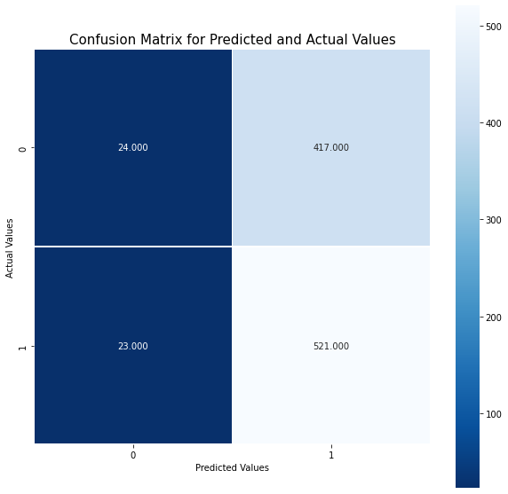

```python
# plot confusion matrix for model
conf_matrix(lag1_Model_predictions, ytrain)
print("Accuracy:", lag1_Model_score)
```

```
[[ 23 418]
 [ 20 524]]
Accuracy: 0.5480769230769231
```

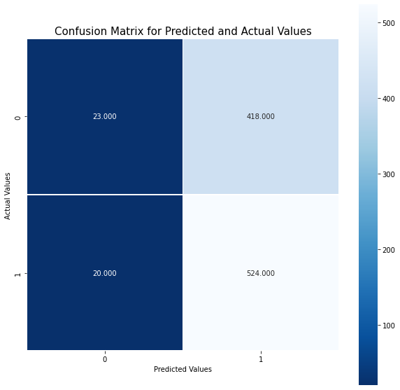

```python
# plot confusion matrix for model
conf_matrix(lag2_Model_predictions, ytrain)
print("Accuracy:", lag2_Model_score)
```

```
[[  0 441]
 [  0 544]]
Accuracy: 0.5865384615384616
```

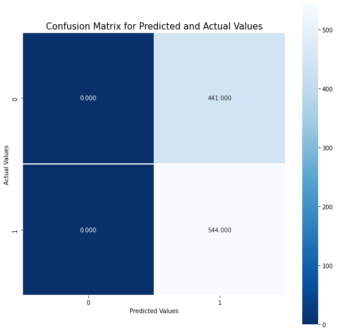

```python
# plot confusion matrix for model
conf_matrix(lag3_Model_predictions, ytrain)
print("Accuracy:", lag3_Model_score)
```

```
[[  0 441]
 [  0 544]]
Accuracy: 0.5865384615384616
```

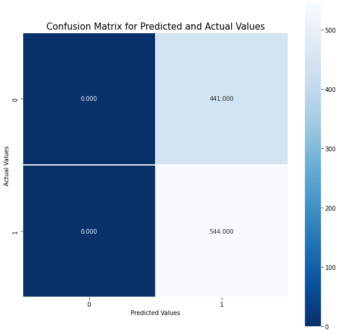

```python
# plot confusion matrix for model
conf_matrix(lag4_Model_predictions, ytrain)
print("Accuracy:", lag4_Model_score)
```

```
[[  2 439]
 [  4 540]]
Accuracy: 0.5096153846153846
```

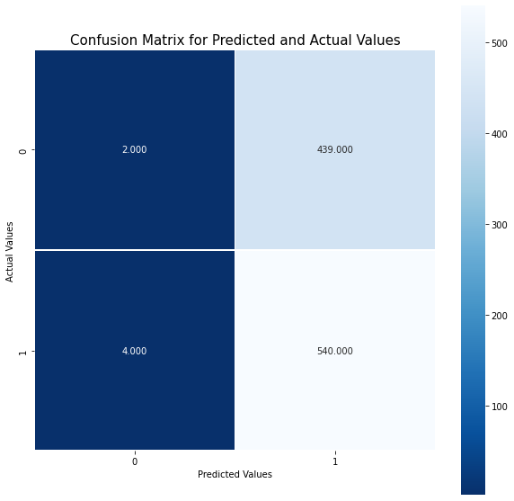

```python
# plot confusion matrix for model
conf_matrix(lag5_Model_predictions, ytrain)
print("Accuracy:", lag5_Model_score)
```

### Task: 10 A

Task: 10 B

# Question: 4

Part A

```
No Skill: ROC AUC=0.500
Logistic: ROC AUC=0.903
```

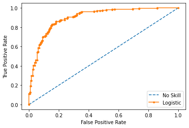

```python
# roc curve and auc
from sklearn.datasets import make_classification
from sklearn.linear_model import LogisticRegression
from sklearn.model_selection import train_test_split
from sklearn.metrics import roc_curve
from sklearn.metrics import roc_auc_score
from matplotlib import pyplot
# generate 2 class dataset
X, y = make_classification(n_samples=1000, n_classes=2, random_state=1)
# split into train/test sets
trainX, testX, trainy, testy = train_test_split(X, y, test_size=0.5, random_state=2)
# generate a no skill prediction (majority class)
ns_probs = [0 for _ in range(len(testy))]
# fit a model
model = LogisticRegression(solver='lbfgs')
model.fit(trainX, trainy)
# predict probabilities
lr_probs = model.predict_proba(testX)
# keep probabilities for the positive outcome only
lr_probs = lr_probs[:, 1]
# calculate scores
ns_auc = roc_auc_score(testy, ns_probs)
lr_auc = roc_auc_score(testy, lr_probs)
# summarize scores
print('No Skill: ROC AUC=%.3f' % (ns_auc))
print('Logistic: ROC AUC=%.3f' % (lr_auc))
# calculate roc curves
ns_fpr, ns_tpr, _ = roc_curve(testy, ns_probs)
lr_fpr, lr_tpr, _ = roc_curve(testy, lr_probs)
# plot the roc curve for the model
pyplot.plot(ns_fpr, ns_tpr, linestyle='--', label='No Skill')
pyplot.plot(lr_fpr, lr_tpr, marker='.', label='Logistic')
# axis labels
pyplot.xlabel('False Positive Rate')
pyplot.ylabel('True Positive Rate')
# show the legend
pyplot.legend()
# show the plot
pyplot.show()
```

Part B

```
Logistic: f1=0.841 auc=0.898
```

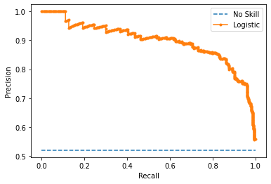

```python
from sklearn.datasets import make_classification
from sklearn.linear_model import LogisticRegression
from sklearn.model_selection import train_test_split
from sklearn.metrics import precision_recall_curve
from sklearn.metrics import f1_score
from sklearn.metrics import auc
from matplotlib import pyplot
# generate 2 class dataset
X, y = make_classification(n_samples=1000, n_classes=2, random_state=1)
# split into train/test sets
trainX, testX, trainy, testy = train_test_split(X, y, test_size=0.5, random_state=2)
# fit a model
model = LogisticRegression(solver='lbfgs')
model.fit(trainX, trainy)
# predict probabilities
lr_probs = model.predict_proba(testX)
# keep probabilities for the positive outcome only
lr_probs = lr_probs[:, 1]
# predict class values
yhat = model.predict(testX)
lr_precision, lr_recall, _ = precision_recall_curve(testy, lr_probs)
lr_f1, lr_auc = f1_score(testy, yhat), auc(lr_recall, lr_precision)
# summarize scores
print('Logistic: f1=%.3f auc=%.3f' % (lr_f1, lr_auc))
# plot the precision-recall curves
no_skill = len(testy[testy==1]) / len(testy)
pyplot.plot([0, 1], [no_skill, no_skill], linestyle='--', label='No Skill')
pyplot.plot(lr_recall, lr_precision, marker='.', label='Logistic')
# axis labels
pyplot.xlabel('Recall')
pyplot.ylabel('Precision')
# show the legend
pyplot.legend()
# show the plot
pyplot.show()
```

Part C

```python
# Importing the KNN Classifier
from sklearn.neighbors import KNeighborsClassifier
classifier = KNeighborsClassifier(n_neighbors=5)
classifier.fit(xtrain, ytrain)
```

```
KNeighborsClassifier()
```

```python
# Predicting values
y_pred = classifier.predict(xtest)
```

```python
# Reporting the results
from sklearn.metrics import classification_report, confusion_matrix
print(confusion_matrix(ytest, y_pred))
print(classification_report(ytest, y_pred))
```

```
[[19 24]
 [28 33]]
              precision    recall  f1-score   support

        Down       0.40      0.44      0.42        43
          Up       0.58      0.54      0.56        61

    accuracy                           0.50       104
   macro avg       0.49      0.49      0.49       104
weighted avg       0.51      0.50      0.50       104
```

```python
error = []

# Calculating error for K values between 1 and 40
for i in range(1, 40):
    knn = KNeighborsClassifier(n_neighbors=i)
    knn_acc=knn.fit(xtrain, ytrain)
    pred_i = knn.predict(xtest)
    error.append(np.mean(pred_i != ytest))
```

```python
# Importing the LabelEncoder
from sklearn.preprocessing import LabelEncoder
le = LabelEncoder()
label = le.fit_transform(ytest)
ytest=label
print(ytest)
from sklearn.preprocessing import LabelEncoder
le = LabelEncoder()
label = le.fit_transform(pred_i)
pred_i=label
print(pred_i)
```

```
[0 0 0 0 1 0 0 0 0 1 1 1 1 1 1 0 1 1 0 1 1 1 1 0 0 0 0 1 1 1 1 0 1 1 0 1 1
 0 0 1 1 0 0 1 1 0 1 1 1 0 1 0 1 0 0 0 0 1 1 0 1 1 1 1 1 1 0 1 0 0 1 0 1 0
 1 1 0 0 1 0 1 0 1 0 0 0 1 1 1 1 0 1 1 1 1 1 0 1 0 1 1 1 1 1]
[0 1 1 0 1 0 1 1 0 1 0 1 1 1 0 1 1 0 0 1 0 1 0 1 1 1 1 1 1 1 1 1 0 0 1 1 0
 0 1 1 1 1 1 1 1 1 0 1 0 0 1 1 0 0 1 1 0 1 0 1 1 0 1 0 1 0 1 1 1 1 1 0 1 0
 1 1 1 1 1 1 1 1 1 1 1 0 1 0 1 1 1 0 1 1 0 1 1 1 1 1 0 1 1 1]
```

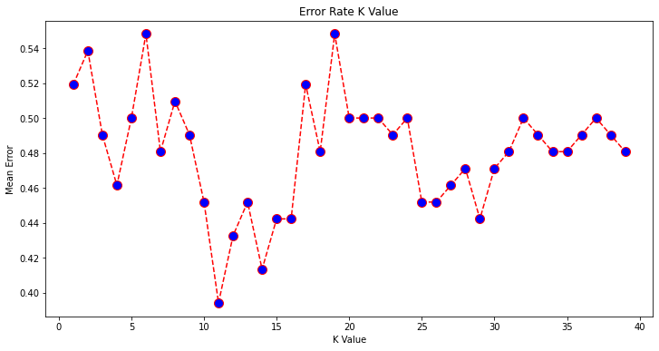

```python
# Plotting the KNN Graph
plt.figure(figsize=(12, 6))
plt.plot(range(1, 40), error, color='red', linestyle='dashed', marker='o',
         markerfacecolor='blue', markersize=10)
plt.title('Error Rate K Value')
plt.xlabel('K Value')
plt.ylabel('Mean Error')
```

Part D

```python
# Setting up the decision tree model
from sklearn import tree
decision_tree = tree.DecisionTreeClassifier()
decision_tree = decision_tree.fit(xtrain, ytrain)
```

```python
# Predicting the values
res_pred = decision_tree.predict(xtest)
Decesion_tree_acc = decision_tree.score(xtest, res_pred)
print(Decesion_tree_acc)
```

```
1.0
```

Plot The Graph of Decision Tree Model

```python
# Plotting the decision tree graph
clf = tree.DecisionTreeClassifier(min_samples_leaf=20, random_state=10)
clf = clf.fit(xtrain, ytrain)
```

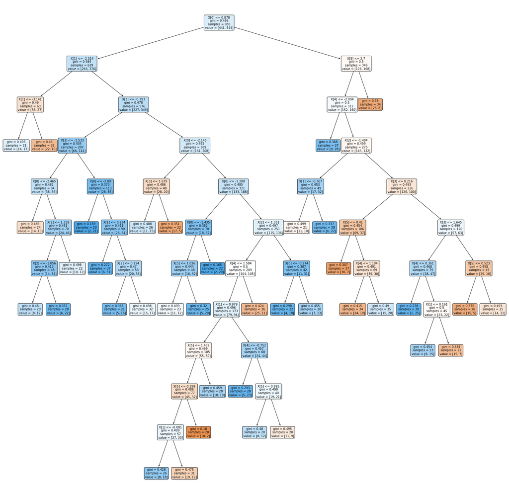

```python
# Importing the decision tree model
from sklearn import tree
plt.figure(figsize=(30, 30))
tree.plot_tree(clf, fontsize = 10,rounded = True , filled = True);
```

```python
!jupyter nbconvert --to html Assignment3.ipynb
```

[output not shown]

[output cut: 75 more lines]

[output not shown]